```python
import numpy as np
import pandas as pd
import matplotlib.pyplot as plt
lok=["January","February","March","April","May","June","July","August","September","October","November","December"]
```

```python
an2019=pd.concat([sales_January,sales_February,sales_March,sales_April,sales_May,sales_June,sales_July,sales_August,sales_September,sales_October,sales_November,sales_December])
an2019
```

|  | Order ID | Product | Quantity Ordered | Price Each | Order Date | Purchase Address |
| --- | --- | --- | --- | --- | --- | --- |
| 0 | 141234 | iPhone | 1 | 700 | 01/22/19 21:25 | 944 Walnut St, Boston, MA 02215 |
| 1 | 141235 | Lightning Charging Cable | 1 | 14.95 | 01/28/19 14:15 | 185 Maple St, Portland, OR 97035 |
| 2 | 141236 | Wired Headphones | 2 | 11.99 | 01/17/19 13:33 | 538 Adams St, San Francisco, CA 94016 |
| 3 | 141237 | 27in FHD Monitor | 1 | 149.99 | 01/05/19 20:33 | 738 10th St, Los Angeles, CA 90001 |
| 4 | 141238 | Wired Headphones | 1 | 11.99 | 01/25/19 11:59 | 387 10th St, Austin, TX 73301 |
| ... | ... | ... | ... | ... | ... | ... |
| 25112 | 319666 | Lightning Charging Cable | 1 | 14.95 | 12/11/19 20:58 | 14 Madison St, San Francisco, CA 94016 |
| 25113 | 319667 | AA Batteries (4-pack) | 2 | 3.84 | 12/01/19 12:01 | 549 Willow St, Los Angeles, CA 90001 |
| 25114 | 319668 | Vareebadd Phone | 1 | 400 | 12/09/19 06:43 | 273 Wilson St, Seattle, WA 98101 |
| 25115 | 319669 | Wired Headphones | 1 | 11.99 | 12/03/19 10:39 | 778 River St, Dallas, TX 75001 |
| 25116 | 319670 | Bose SoundSport Headphones | 1 | 99.99 | 12/21/19 21:45 | 747 Chestnut St, Los Angeles, CA 90001 |

186850 rows × 6 columns

```python
an2019.dropna(inplace=True)
```

```python
an2019
```

|  | Order ID | Product | Quantity Ordered | Price Each | Order Date | Purchase Address |
| --- | --- | --- | --- | --- | --- | --- |
| 0 | 141234 | iPhone | 1 | 700 | 01/22/19 21:25 | 944 Walnut St, Boston, MA 02215 |
| 1 | 141235 | Lightning Charging Cable | 1 | 14.95 | 01/28/19 14:15 | 185 Maple St, Portland, OR 97035 |
| 2 | 141236 | Wired Headphones | 2 | 11.99 | 01/17/19 13:33 | 538 Adams St, San Francisco, CA 94016 |
| 3 | 141237 | 27in FHD Monitor | 1 | 149.99 | 01/05/19 20:33 | 738 10th St, Los Angeles, CA 90001 |
| 4 | 141238 | Wired Headphones | 1 | 11.99 | 01/25/19 11:59 | 387 10th St, Austin, TX 73301 |
| ... | ... | ... | ... | ... | ... | ... |
| 25112 | 319666 | Lightning Charging Cable | 1 | 14.95 | 12/11/19 20:58 | 14 Madison St, San Francisco, CA 94016 |
| 25113 | 319667 | AA Batteries (4-pack) | 2 | 3.84 | 12/01/19 12:01 | 549 Willow St, Los Angeles, CA 90001 |
| 25114 | 319668 | Vareebadd Phone | 1 | 400 | 12/09/19 06:43 | 273 Wilson St, Seattle, WA 98101 |
| 25115 | 319669 | Wired Headphones | 1 | 11.99 | 12/03/19 10:39 | 778 River St, Dallas, TX 75001 |
| 25116 | 319670 | Bose SoundSport Headphones | 1 | 99.99 | 12/21/19 21:45 | 747 Chestnut St, Los Angeles, CA 90001 |

186305 rows × 6 columns

```python
an2019.loc[~an2019['Order ID'].str.isdigit(),:]
```

|  | Order ID | Product | Quantity Ordered | Price Each | Order Date | Purchase Address |
| --- | --- | --- | --- | --- | --- | --- |
| 1073 | Order ID | Product | Quantity Ordered | Price Each | Order Date | Purchase Address |
| 1102 | Order ID | Product | Quantity Ordered | Price Each | Order Date | Purchase Address |
| 1194 | Order ID | Product | Quantity Ordered | Price Each | Order Date | Purchase Address |
| 1897 | Order ID | Product | Quantity Ordered | Price Each | Order Date | Purchase Address |
| 2463 | Order ID | Product | Quantity Ordered | Price Each | Order Date | Purchase Address |
| ... | ... | ... | ... | ... | ... | ... |
| 23198 | Order ID | Product | Quantity Ordered | Price Each | Order Date | Purchase Address |
| 23337 | Order ID | Product | Quantity Ordered | Price Each | Order Date | Purchase Address |
| 23748 | Order ID | Product | Quantity Ordered | Price Each | Order Date | Purchase Address |
| 24192 | Order ID | Product | Quantity Ordered | Price Each | Order Date | Purchase Address |
| 24222 | Order ID | Product | Quantity Ordered | Price Each | Order Date | Purchase Address |

355 rows × 6 columns

```python
an2019=an2019.drop(an2019.loc[an2019['Order ID']=='Order ID',:].index)
```

```python
an2019
```

|  | Order ID | Product | Quantity Ordered | Price Each | Order Date | Purchase Address |
| --- | --- | --- | --- | --- | --- | --- |
| 0 | 141234 | iPhone | 1 | 700 | 01/22/19 21:25 | 944 Walnut St, Boston, MA 02215 |
| 1 | 141235 | Lightning Charging Cable | 1 | 14.95 | 01/28/19 14:15 | 185 Maple St, Portland, OR 97035 |
| 2 | 141236 | Wired Headphones | 2 | 11.99 | 01/17/19 13:33 | 538 Adams St, San Francisco, CA 94016 |
| 3 | 141237 | 27in FHD Monitor | 1 | 149.99 | 01/05/19 20:33 | 738 10th St, Los Angeles, CA 90001 |
| 4 | 141238 | Wired Headphones | 1 | 11.99 | 01/25/19 11:59 | 387 10th St, Austin, TX 73301 |
| ... | ... | ... | ... | ... | ... | ... |
| 25112 | 319666 | Lightning Charging Cable | 1 | 14.95 | 12/11/19 20:58 | 14 Madison St, San Francisco, CA 94016 |
| 25113 | 319667 | AA Batteries (4-pack) | 2 | 3.84 | 12/01/19 12:01 | 549 Willow St, Los Angeles, CA 90001 |
| 25114 | 319668 | Vareebadd Phone | 1 | 400 | 12/09/19 06:43 | 273 Wilson St, Seattle, WA 98101 |
| 25115 | 319669 | Wired Headphones | 1 | 11.99 | 12/03/19 10:39 | 778 River St, Dallas, TX 75001 |
| 25116 | 319670 | Bose SoundSport Headphones | 1 | 99.99 | 12/21/19 21:45 | 747 Chestnut St, Los Angeles, CA 90001 |

182735 rows × 6 columns

```python
an2019['Price Each']=pd.to_numeric(an2019['Price Each'])
an2019=an2019.reset_index()
```

```python
an2019['Quantity Ordered']=an2019['Quantity Ordered'].astype(int)
an2019['Price Each']=an2019['Price Each'].astype(float)
an2019
```

[output not shown]

182735 rows × 6 columns

```python
an2019['Order Date']=pd.to_datetime(an2019['Order Date'])
```

```python
an2019.sort_index(inplace=True)
an2019
```

|  | Order Date | Order ID | Product | Quantity Ordered | Price Each | Purchase Address |
| --- | --- | --- | --- | --- | --- | --- |
| 0 | 2019-01-01 03:07:00 | 147268 | Wired Headphones | 1 | 11.99 | 9 Lake St, New York City, NY 10001 |
| 1 | 2019-01-01 03:40:00 | 148041 | USB-C Charging Cable | 1 | 11.95 | 760 Church St, San Francisco, CA 94016 |
| 2 | 2019-01-01 04:56:00 | 149343 | Apple Airpods Headphones | 1 | 150.00 | 735 5th St, New York City, NY 10001 |
| 3 | 2019-01-01 05:53:00 | 149964 | AAA Batteries (4-pack) | 1 | 2.99 | 75 Jackson St, Dallas, TX 75001 |
| 4 | 2019-01-01 06:03:00 | 149350 | USB-C Charging Cable | 2 | 11.95 | 943 2nd St, Atlanta, GA 30301 |
| ... | ... | ... | ... | ... | ... | ... |
| 182730 | 2019-12-31 23:42:00 | 298406 | AAA Batteries (4-pack) | 2 | 2.99 | 30 Elm St, San Francisco, CA 94016 |
| 182731 | 2019-12-31 23:42:00 | 297481 | AA Batteries (4-pack) | 1 | 3.84 | 82 Hill St, Dallas, TX 75001 |
| 182732 | 2019-12-31 23:45:00 | 317048 | AAA Batteries (4-pack) | 2 | 2.99 | 743 Adams St, San Francisco, CA 94016 |
| 182733 | 2019-12-31 23:52:00 | 309773 | AAA Batteries (4-pack) | 1 | 2.99 | 60 Hickory St, Los Angeles, CA 90001 |
| 182734 | 2019-12-31 23:53:00 | 297674 | AAA Batteries (4-pack) | 1 | 2.99 | 425 Lake St, Portland, OR 97035 |

182735 rows × 6 columns

```python
an2019
```

[output not shown]

182735 rows × 5 columns

```python
an2019.iloc[10031,:]
```

```
Order Date                          2019-02-02 12:21:00
Order ID                                         153891
Product                                          iPhone
Quantity Ordered                                      1
Price Each                                        700.0
Purchase Address    934 6th St, San Francisco, CA 94016
Name: 10031, dtype: object
```

```python
#Meilleur moi de vente
#Chiffre d'affaires
an2019['CA']=an2019['Quantity Ordered']*an2019['Price Each']
an2019
```

[output not shown]

182735 rows × 7 columns

```python
an2019
```

| Order Date | Order ID | Product | Quantity Ordered | Price Each | Purchase Address | mois | CA |
| --- | --- | --- | --- | --- | --- | --- | --- |
| 2019-01-01 03:07:00 | 147268 | Wired Headphones | 1 | 11.99 | 9 Lake St, New York City, NY 10001 | January | 11.99 |
| 2019-01-01 03:40:00 | 148041 | USB-C Charging Cable | 1 | 11.95 | 760 Church St, San Francisco, CA 94016 | January | 11.95 |
| 2019-01-01 04:56:00 | 149343 | Apple Airpods Headphones | 1 | 150.00 | 735 5th St, New York City, NY 10001 | January | 150.00 |
| 2019-01-01 05:53:00 | 149964 | AAA Batteries (4-pack) | 1 | 2.99 | 75 Jackson St, Dallas, TX 75001 | January | 2.99 |
| 2019-01-01 06:03:00 | 149350 | USB-C Charging Cable | 2 | 11.95 | 943 2nd St, Atlanta, GA 30301 | January | 23.90 |
| ... | ... | ... | ... | ... | ... | ... | ... |
| 2020-01-01 04:13:00 | 304165 | AAA Batteries (4-pack) | 1 | 2.99 | 825 Adams St, Portland, OR 97035 | January | 2.99 |
| 2020-01-01 04:21:00 | 299125 | USB-C Charging Cable | 1 | 11.95 | 754 Hickory St, New York City, NY 10001 | January | 11.95 |
| 2020-01-01 04:54:00 | 305840 | Bose SoundSport Headphones | 1 | 99.99 | 784 River St, San Francisco, CA 94016 | January | 99.99 |
| 2020-01-01 05:13:00 | 300519 | Lightning Charging Cable | 1 | 14.95 | 657 Spruce St, New York City, NY 10001 | January | 14.95 |
| 2020-01-01 05:13:00 | 300519 | Bose SoundSport Headphones | 1 | 99.99 | 657 Spruce St, New York City, NY 10001 | January | 99.99 |

182735 rows × 7 columns

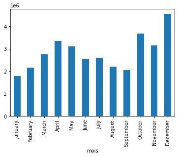

```python
u=an2019.groupby('mois')['CA'].sum().loc[lok]
u.plot.bar()
```

```python
#ville ou l'on vend le plus de produit
an2019['Purchase Address'].unique()
```

```
array(['9 Lake St, New York City, NY 10001',
       '760 Church St, San Francisco, CA 94016',
       '735 5th St, New York City, NY 10001', ...,
       '731 7th St, New York City, NY 10001',
       '754 Hickory St, New York City, NY 10001',
       '657 Spruce St, New York City, NY 10001'], dtype=object)
```

```python
'9 Lake St, New York City, NY 10001'.split(',')[1].strip()
```

```
'New York City'
```

```python
def ville(adress):
    return adress.split(',')[1].strip()
```

```python
an2019['ville']=an2019['Purchase Address'].apply(ville)
an2019
```

| Order Date | Order ID | Product | Quantity Ordered | Price Each | Purchase Address | mois | CA | ville |
| --- | --- | --- | --- | --- | --- | --- | --- | --- |
| 2019-01-01 03:07:00 | 147268 | Wired Headphones | 1 | 11.99 | 9 Lake St, New York City, NY 10001 | January | 11.99 | New York City |
| 2019-01-01 03:40:00 | 148041 | USB-C Charging Cable | 1 | 11.95 | 760 Church St, San Francisco, CA 94016 | January | 11.95 | San Francisco |
| 2019-01-01 04:56:00 | 149343 | Apple Airpods Headphones | 1 | 150.00 | 735 5th St, New York City, NY 10001 | January | 150.00 | New York City |
| 2019-01-01 05:53:00 | 149964 | AAA Batteries (4-pack) | 1 | 2.99 | 75 Jackson St, Dallas, TX 75001 | January | 2.99 | Dallas |
| 2019-01-01 06:03:00 | 149350 | USB-C Charging Cable | 2 | 11.95 | 943 2nd St, Atlanta, GA 30301 | January | 23.90 | Atlanta |
| ... | ... | ... | ... | ... | ... | ... | ... | ... |
| 2020-01-01 04:13:00 | 304165 | AAA Batteries (4-pack) | 1 | 2.99 | 825 Adams St, Portland, OR 97035 | January | 2.99 | Portland |
| 2020-01-01 04:21:00 | 299125 | USB-C Charging Cable | 1 | 11.95 | 754 Hickory St, New York City, NY 10001 | January | 11.95 | New York City |
| 2020-01-01 04:54:00 | 305840 | Bose SoundSport Headphones | 1 | 99.99 | 784 River St, San Francisco, CA 94016 | January | 99.99 | San Francisco |
| 2020-01-01 05:13:00 | 300519 | Lightning Charging Cable | 1 | 14.95 | 657 Spruce St, New York City, NY 10001 | January | 14.95 | New York City |
| 2020-01-01 05:13:00 | 300519 | Bose SoundSport Headphones | 1 | 99.99 | 657 Spruce St, New York City, NY 10001 | January | 99.99 | New York City |

182735 rows × 8 columns

```python
an2019['Purchase Address']
```

```
Order Date
2019-01-01 03:07:00         9 Lake St, New York City, NY 10001
2019-01-01 03:40:00     760 Church St, San Francisco, CA 94016
2019-01-01 04:56:00        735 5th St, New York City, NY 10001
2019-01-01 05:53:00            75 Jackson St, Dallas, TX 75001
2019-01-01 06:03:00              943 2nd St, Atlanta, GA 30301
                                        ...
2020-01-01 04:13:00           825 Adams St, Portland, OR 97035
2020-01-01 04:21:00    754 Hickory St, New York City, NY 10001
2020-01-01 04:54:00      784 River St, San Francisco, CA 94016
2020-01-01 05:13:00     657 Spruce St, New York City, NY 10001
2020-01-01 05:13:00     657 Spruce St, New York City, NY 10001
Name: Purchase Address, Length: 182735, dtype: object
```

```python
an2019
```

[output not shown]

182735 rows × 7 columns

```python
il=an2019.iloc[:,[2,4]]
il=il.reset_index()
del il['Order Date']
il.groupby('Purchase Address').agg('Quantity Ordered').sum()
```

```
Purchase Address
1 11th St, Atlanta, GA 30301              1
1 11th St, Los Angeles, CA 90001          1
1 11th St, San Francisco, CA 94016        1
1 12th St, Los Angeles, CA 90001          1
1 12th St, New York City, NY 10001        1
                                         ..
999 Wilson St, Atlanta, GA 30301          1
999 Wilson St, Los Angeles, CA 90001      1
999 Wilson St, New York City, NY 10001    1
999 Wilson St, Portland, OR 97035         1
999 Wilson St, San Francisco, CA 94016    1
Name: Quantity Ordered, Length: 138946, dtype: int32
```

```python
il.reset_index()
```

|  | index | Quantity Ordered | Purchase Address |
| --- | --- | --- | --- |
| 0 | 0 | 1 | 9 Lake St, New York City, NY 10001 |
| 1 | 1 | 1 | 760 Church St, San Francisco, CA 94016 |
| 2 | 2 | 1 | 735 5th St, New York City, NY 10001 |
| 3 | 3 | 1 | 75 Jackson St, Dallas, TX 75001 |
| 4 | 4 | 2 | 943 2nd St, Atlanta, GA 30301 |
| ... | ... | ... | ... |
| 182730 | 182730 | 1 | 825 Adams St, Portland, OR 97035 |
| 182731 | 182731 | 1 | 754 Hickory St, New York City, NY 10001 |
| 182732 | 182732 | 1 | 784 River St, San Francisco, CA 94016 |
| 182733 | 182733 | 1 | 657 Spruce St, New York City, NY 10001 |
| 182734 | 182734 | 1 | 657 Spruce St, New York City, NY 10001 |

182735 rows × 3 columns

```python
an2019
```

[output not shown]

182735 rows × 5 columns

• Dans quelle ville vend-on le plus de produits ? • Quel est le meilleur mois de vente ? et quel est le chiffre d’affaire de ce mois ? • A quelle heure devons-nous passer les publicités pour attirer plus de monde • Quelles sont les produits qui sont souvent achetés ensemble. • Quel produit a-t-on le plus vendu et pourquoi ?

```python
#Dans quelle ville vend-on le plus de Produits
#construisons une collone CA
```

pour connaitre la ville la plus rentable il faut déterminer d'abord son chiffre d'affaire pour cela calculons creons une colonne CA qui est égale a PRIX* Quantité

```python
an2019['CA']=an2019['Quantity Ordered']*an2019['Price Each']
#la colonne a été crée via cette ligne de code
def ville(ko):
    return ko.split(',')[1].strip()
an2019['Ville']=an2019['Purchase Address'].apply(ville)
#la colonne ville a été  crée via cette ligne de commande
an2019
```

| Order Date | Order ID | Product | Quantity Ordered | Price Each | Purchase Address | CA | Ville |
| --- | --- | --- | --- | --- | --- | --- | --- |
| 2019-01-01 03:07:00 | 147268 | Wired Headphones | 1 | 11.99 | 9 Lake St, New York City, NY 10001 | 11.99 | New York City |
| 2019-01-01 03:40:00 | 148041 | USB-C Charging Cable | 1 | 11.95 | 760 Church St, San Francisco, CA 94016 | 11.95 | San Francisco |
| 2019-01-01 04:56:00 | 149343 | Apple Airpods Headphones | 1 | 150.00 | 735 5th St, New York City, NY 10001 | 150.00 | New York City |
| 2019-01-01 05:53:00 | 149964 | AAA Batteries (4-pack) | 1 | 2.99 | 75 Jackson St, Dallas, TX 75001 | 2.99 | Dallas |
| 2019-01-01 06:03:00 | 149350 | USB-C Charging Cable | 2 | 11.95 | 943 2nd St, Atlanta, GA 30301 | 23.90 | Atlanta |
| ... | ... | ... | ... | ... | ... | ... | ... |
| 2019-12-31 23:42:00 | 298406 | AAA Batteries (4-pack) | 2 | 2.99 | 30 Elm St, San Francisco, CA 94016 | 5.98 | San Francisco |
| 2019-12-31 23:42:00 | 297481 | AA Batteries (4-pack) | 1 | 3.84 | 82 Hill St, Dallas, TX 75001 | 3.84 | Dallas |
| 2019-12-31 23:45:00 | 317048 | AAA Batteries (4-pack) | 2 | 2.99 | 743 Adams St, San Francisco, CA 94016 | 5.98 | San Francisco |
| 2019-12-31 23:52:00 | 309773 | AAA Batteries (4-pack) | 1 | 2.99 | 60 Hickory St, Los Angeles, CA 90001 | 2.99 | Los Angeles |
| 2019-12-31 23:53:00 | 297674 | AAA Batteries (4-pack) | 1 | 2.99 | 425 Lake St, Portland, OR 97035 | 2.99 | Portland |

182735 rows × 7 columns

Les colonnes ainsi crée l'on peut repondre à la premiere question Nous allons utiliser les deux clonne crée

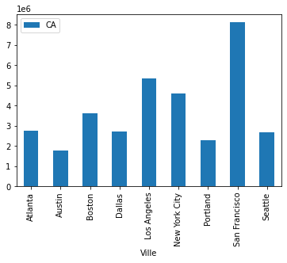

```python
V=an2019.iloc[:,[5,6]]
V=V.reset_index()
del V['Order Date']
V=V.groupby('Ville').sum()
V.sort_values('CA',ascending=[False])
V.groupby('Ville').sum().plot.bar()
```

D'apres ce graphique San Francisco est la ville leadeuse du supermarché

```python
#Quel est le meilleur mois de vente ? et quel est le chiffre d’affaire de ce mois ?
#Pour cela il faudra creer une colonne Month
#et ensuite faire une relation entre cette colonne et le CA
```

```python
an2019['Month']=an2019.index.month_name()
an2019
```

| Order Date | Order ID | Product | Quantity Ordered | Price Each | Purchase Address | CA | Ville | Month |
| --- | --- | --- | --- | --- | --- | --- | --- | --- |
| 2019-01-01 03:07:00 | 147268 | Wired Headphones | 1 | 11.99 | 9 Lake St, New York City, NY 10001 | 11.99 | New York City | January |
| 2019-01-01 03:40:00 | 148041 | USB-C Charging Cable | 1 | 11.95 | 760 Church St, San Francisco, CA 94016 | 11.95 | San Francisco | January |
| 2019-01-01 04:56:00 | 149343 | Apple Airpods Headphones | 1 | 150.00 | 735 5th St, New York City, NY 10001 | 150.00 | New York City | January |
| 2019-01-01 05:53:00 | 149964 | AAA Batteries (4-pack) | 1 | 2.99 | 75 Jackson St, Dallas, TX 75001 | 2.99 | Dallas | January |
| 2019-01-01 06:03:00 | 149350 | USB-C Charging Cable | 2 | 11.95 | 943 2nd St, Atlanta, GA 30301 | 23.90 | Atlanta | January |
| ... | ... | ... | ... | ... | ... | ... | ... | ... |
| 2019-12-31 23:42:00 | 298406 | AAA Batteries (4-pack) | 2 | 2.99 | 30 Elm St, San Francisco, CA 94016 | 5.98 | San Francisco | December |
| 2019-12-31 23:42:00 | 297481 | AA Batteries (4-pack) | 1 | 3.84 | 82 Hill St, Dallas, TX 75001 | 3.84 | Dallas | December |
| 2019-12-31 23:45:00 | 317048 | AAA Batteries (4-pack) | 2 | 2.99 | 743 Adams St, San Francisco, CA 94016 | 5.98 | San Francisco | December |
| 2019-12-31 23:52:00 | 309773 | AAA Batteries (4-pack) | 1 | 2.99 | 60 Hickory St, Los Angeles, CA 90001 | 2.99 | Los Angeles | December |
| 2019-12-31 23:53:00 | 297674 | AAA Batteries (4-pack) | 1 | 2.99 | 425 Lake St, Portland, OR 97035 | 2.99 | Portland | December |

182735 rows × 8 columns

Ainsi creer ,creons une realtion en la colonne Month et le ca

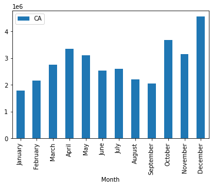

```python
l=['January','February','March','April','May','June','July','August','September','October','November','December']
mois=an2019.iloc[:,[5,7]]
mois=mois.reset_index()
del mois['Order Date']
mois=mois.groupby('Month').sum()
mois.sort_values('CA',ascending=False)
mois.loc[l].plot.bar()
```

```python
#selon le graffe ci dessus les vente  atteingne le plus haut pics en december
```

A quelle heure devons-nous passer les publicités pour attirer plus de monde Pour repondre a cette questions nous allons crer une colonnes Times et créer une relation avec la collone CA

```python
an2019['Time']=an2019.index.hour
#de part cette ligne est crée la collone Time
```

| Order Date | Order ID | Product | Quantity Ordered | Price Each | Purchase Address | CA | Ville | Month | Time |
| --- | --- | --- | --- | --- | --- | --- | --- | --- | --- |
| 2019-01-01 03:07:00 | 147268 | Wired Headphones | 1 | 11.99 | 9 Lake St, New York City, NY 10001 | 11.99 | New York City | January | 3 |
| 2019-01-01 03:40:00 | 148041 | USB-C Charging Cable | 1 | 11.95 | 760 Church St, San Francisco, CA 94016 | 11.95 | San Francisco | January | 3 |
| 2019-01-01 04:56:00 | 149343 | Apple Airpods Headphones | 1 | 150.00 | 735 5th St, New York City, NY 10001 | 150.00 | New York City | January | 4 |
| 2019-01-01 05:53:00 | 149964 | AAA Batteries (4-pack) | 1 | 2.99 | 75 Jackson St, Dallas, TX 75001 | 2.99 | Dallas | January | 5 |
| 2019-01-01 06:03:00 | 149350 | USB-C Charging Cable | 2 | 11.95 | 943 2nd St, Atlanta, GA 30301 | 23.90 | Atlanta | January | 6 |
| ... | ... | ... | ... | ... | ... | ... | ... | ... | ... |
| 2019-12-31 23:42:00 | 298406 | AAA Batteries (4-pack) | 2 | 2.99 | 30 Elm St, San Francisco, CA 94016 | 5.98 | San Francisco | December | 23 |
| 2019-12-31 23:42:00 | 297481 | AA Batteries (4-pack) | 1 | 3.84 | 82 Hill St, Dallas, TX 75001 | 3.84 | Dallas | December | 23 |
| 2019-12-31 23:45:00 | 317048 | AAA Batteries (4-pack) | 2 | 2.99 | 743 Adams St, San Francisco, CA 94016 | 5.98 | San Francisco | December | 23 |
| 2019-12-31 23:52:00 | 309773 | AAA Batteries (4-pack) | 1 | 2.99 | 60 Hickory St, Los Angeles, CA 90001 | 2.99 | Los Angeles | December | 23 |
| 2019-12-31 23:53:00 | 297674 | AAA Batteries (4-pack) | 1 | 2.99 | 425 Lake St, Portland, OR 97035 | 2.99 | Portland | December | 23 |

182735 rows × 9 columns

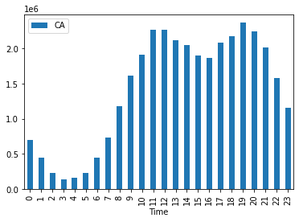

```python
Ti=an2019.iloc[:,[5,8]]
Ti=Ti.reset_index()
del Ti['Order Date']
Ti=Ti.groupby('Time').sum()

Ti.sort_values('CA',ascending=False)
Ti.plot.bar()
```

d'apres le graphique ci dessous les heure propice a une bonne vente sont 11H à 12h et dans la soirée18h à 19hQuelles sont les produits qui sont souvent achetés ensemble? Pour repondre a ces question il faudra passer par une methode de combinaisons et de decompte dans les librairie collections et Nous allons utiliser deux collones l'Order ID et le Product

```python
aD=an2019.iloc[:,[0,1]]
aD=aD[aD['Order ID'].duplicated(keep=False)]
aD=aD.reset_index()
def doublons(p:list):
    return ';'.join(p)
del aD['Order Date']
aD=aD.groupby('Order ID')['Product'].apply(doublons)
aD
```

```
Order ID
141275              USB-C Charging Cable;Wired Headphones
141290     Apple Airpods Headphones;AA Batteries (4-pack)
141365                   Vareebadd Phone;Wired Headphones
141384                  USB-C Charging Cable;Google Phone
141450            Google Phone;Bose SoundSport Headphones
                               ...
319536                Wired Headphones;Macbook Pro Laptop
319556                      Wired Headphones;Google Phone
319584                            Wired Headphones;iPhone
319596                    iPhone;Lightning Charging Cable
319631    34in Ultrawide Monitor;Lightning Charging Cable
Name: Product, Length: 6928, dtype: object
```

```python
from itertools import combinations
from collections import Counter
count=Counter()
Counter(combinations(['A','b','k','o'],2))
```

```
Counter({('A', 'b'): 1,
         ('A', 'k'): 1,
         ('A', 'o'): 1,
         ('b', 'k'): 1,
         ('b', 'o'): 1,
         ('k', 'o'): 1})
```

```python
aD.to_list()
```

```
['USB-C Charging Cable;Wired Headphones',
 'Apple Airpods Headphones;AA Batteries (4-pack)',
 'Vareebadd Phone;Wired Headphones',
 'USB-C Charging Cable;Google Phone',
 'Google Phone;Bose SoundSport Headphones',
 'Apple Airpods Headphones;iPhone',
 'Google Phone;Apple Airpods Headphones',
 'iPhone;Wired Headphones;Apple Airpods Headphones',
 'USB-C Charging Cable;Apple Airpods Headphones',
 'Lightning Charging Cable;Wired Headphones',
 'iPhone;Lightning Charging Cable',
 'Bose SoundSport Headphones;27in FHD Monitor',
 'USB-C Charging Cable;Google Phone',
 'iPhone;Wired Headphones',
 'USB-C Charging Cable;Google Phone',
 'AAA Batteries (4-pack);AA Batteries (4-pack)',
 'USB-C Charging Cable;Vareebadd Phone;Wired Headphones',
 'USB-C Charging Cable;Google Phone',
 'Vareebadd Phone;Wired Headphones',
 'Lightning Charging Cable;34in Ultrawide Monitor',
 'Wired Headphones;USB-C Charging Cable',
 'Lightning Charging Cable;Bose SoundSport Headphones',
 'Google Phone;Wired Headphones',
 'Wired Headphones;iPhone',
 'Lightning Charging Cable;Apple Airpods Headphones',
 'iPhone;Google Phone',
 'iPhone;Wired Headphones',
 'iPhone;Lightning Charging Cable',
 'Wired Headphones;20in Monitor',
 'Apple Airpods Headphones;iPhone',
 'Google Phone;USB-C Charging Cable',
 'Wired Headphones;Google Phone',
 'AA Batteries (4-pack);AA Batteries (4-pack)',
 'Lightning Charging Cable;iPhone',
 'Bose SoundSport Headphones;20in Monitor',
 'Wired Headphones;Bose SoundSport Headphones;Google Phone',
 'Vareebadd Phone;USB-C Charging Cable',
 'USB-C Charging Cable;Apple Airpods Headphones',
 'USB-C Charging Cable;Google Phone',
 'USB-C Charging Cable;Google Phone',
```

[output cut: 946 more lines]

```
 'Lightning Charging Cable;USB-C Charging Cable',
 'ThinkPad Laptop;Lightning Charging Cable',
 'Wired Headphones;iPhone',
 'Vareebadd Phone;27in FHD Monitor',
 'Bose SoundSport Headphones;Google Phone',
 'USB-C Charging Cable;Google Phone',
 'Vareebadd Phone;Wired Headphones',
 'Wired Headphones;Lightning Charging Cable',
 'Wired Headphones;Apple Airpods Headphones',
 '27in FHD Monitor;Wired Headphones',
 'Apple Airpods Headphones;Lightning Charging Cable',
 'USB-C Charging Cable;Google Phone',
 'iPhone;Lightning Charging Cable',
 'AAA Batteries (4-pack);iPhone',
 ...]
```

```python
Counter(aD)
```

```
Counter({'USB-C Charging Cable;Wired Headphones': 43,
         'Apple Airpods Headphones;AA Batteries (4-pack)': 40,
         'Vareebadd Phone;Wired Headphones': 59,
         'USB-C Charging Cable;Google Phone': 422,
         'Google Phone;Bose SoundSport Headphones': 83,
         'Apple Airpods Headphones;iPhone': 149,
         'Google Phone;Apple Airpods Headphones': 7,
         'iPhone;Wired Headphones;Apple Airpods Headphones': 2,
         'USB-C Charging Cable;Apple Airpods Headphones': 30,
         'Lightning Charging Cable;Wired Headphones': 36,
         'iPhone;Lightning Charging Cable': 454,
         'Bose SoundSport Headphones;27in FHD Monitor': 12,
         'iPhone;Wired Headphones': 169,
         'AAA Batteries (4-pack);AA Batteries (4-pack)': 36,
         'USB-C Charging Cable;Vareebadd Phone;Wired Headphones': 3,
         'Lightning Charging Cable;34in Ultrawide Monitor': 14,
         'Wired Headphones;USB-C Charging Cable': 39,
         'Lightning Charging Cable;Bose SoundSport Headphones': 36,
         'Google Phone;Wired Headphones': 143,
         'Wired Headphones;iPhone': 199,
         'Lightning Charging Cable;Apple Airpods Headphones': 32,
         'iPhone;Google Phone': 4,
         'Wired Headphones;20in Monitor': 7,
         'Google Phone;USB-C Charging Cable': 418,
         'Wired Headphones;Google Phone': 160,
         'AA Batteries (4-pack);AA Batteries (4-pack)': 35,
         'Lightning Charging Cable;iPhone': 415,
         'Bose SoundSport Headphones;20in Monitor': 8,
         'Wired Headphones;Bose SoundSport Headphones;Google Phone': 2,
         'Vareebadd Phone;USB-C Charging Cable': 161,
         'USB-C Charging Cable;Google Phone;Wired Headphones': 15,
         'Google Phone;iPhone': 2,
         'Vareebadd Phone;Bose SoundSport Headphones': 33,
         'AA Batteries (4-pack);AAA Batteries (4-pack)': 50,
         '27in 4K Gaming Monitor;AAA Batteries (4-pack)': 14,
         'USB-C Charging Cable;AA Batteries (4-pack)': 35,
         'Lightning Charging Cable;USB-C Charging Cable': 52,
         'Macbook Pro Laptop;AA Batteries (4-pack)': 9,
         'Bose SoundSport Headphones;Macbook Pro Laptop': 8,
         'Wired Headphones;34in Ultrawide Monitor': 15,
```

[output cut: 356 more lines]

```
         'Vareebadd Phone;Bose SoundSport Headphones;Wired Headphones': 1,
         'ThinkPad Laptop;27in FHD Monitor': 1,
         'Lightning Charging Cable;Google Phone;USB-C Charging Cable': 1,
         'Wired Headphones;Google Phone;Bose SoundSport Headphones;USB-C Charging Cable': 1,
         'AA Batteries (4-pack);iPhone;Lightning Charging Cable;Wired Headphones': 1,
         'Macbook Pro Laptop;Flatscreen TV': 1,
         'USB-C Charging Cable;iPhone;Vareebadd Phone': 1,
         'Bose SoundSport Headphones;Wired Headphones;Vareebadd Phone': 1,
         'USB-C Charging Cable;Google Phone;Bose SoundSport Headphones;34in Ultrawide Monitor': 1,
         'ThinkPad Laptop;ThinkPad Laptop': 2,
         'Apple Airpods Headphones;iPhone;AAA Batteries (4-pack)': 1,
         '20in Monitor;ThinkPad Laptop': 1,
         'Wired Headphones;Apple Airpods Headphones;Google Phone;USB-C Charging Cable': 1,
         'Apple Airpods Headphones;Lightning Charging Cable;Wired Headphones;iPhone': 1,
         'Lightning Charging Cable;Vareebadd Phone': 1})
```

```python
for S in aD.to_list():
    Porducts= S.split(';')
    print(Porducts)
    count.update(Counter(combinations(Porducts,2)))
```

[output not shown]

[output cut: 6873 more lines]

[output not shown]

```python
count.most_common(1)
#D'apres les recents calcule les produits le plus acheté ensemble sont
```

```
[(('iPhone', 'Lightning Charging Cable'), 511)]
```

Quel produit a-t-on le plus vendu et pourquoi ? Pour repondre a cette question nous allons utiliser deux colonnes celles des produits et celles de la quantité de produits acheté

```python
sd=sd=an2019.iloc[:,[1,2]]
sd=sd.reset_index()
del sd['Order Date']
sd=sd.groupby('Product').sum()
sd=sd.sort_values('Quantity Ordered',ascending=False)
sd
```

| Product | Quantity Ordered |
| --- | --- |
| AAA Batteries (4-pack) | 30487 |
| AA Batteries (4-pack) | 27148 |
| USB-C Charging Cable | 23555 |
| Lightning Charging Cable | 22841 |
| Wired Headphones | 20201 |
| Apple Airpods Headphones | 15383 |
| Bose SoundSport Headphones | 13236 |
| 27in FHD Monitor | 7429 |
| iPhone | 6732 |
| 27in 4K Gaming Monitor | 6134 |
| 34in Ultrawide Monitor | 6076 |
| Google Phone | 5440 |
| Flatscreen TV | 4724 |
| Macbook Pro Laptop | 4645 |
| 20in Monitor | 4058 |
| ThinkPad Laptop | 4054 |
| Vareebadd Phone | 2023 |
| LG Washing Machine | 649 |
| LG Dryer | 640 |

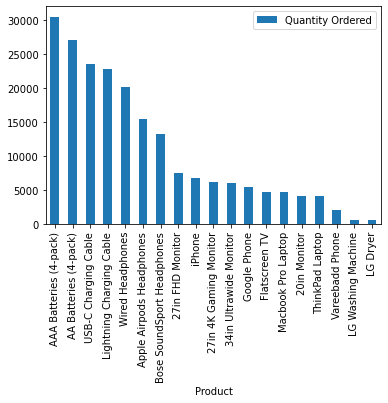

```python
sd.plot.bar()
```

d'apres ce graphe Le produit le plus vendu est le AAA Batteries (4-pack) avec 30487

**Qu’elles sont les valeurs qui peuvent influer sur a et b** ? L’adresse de vente : la ville de vente des produits peut provoquer une fluctuation positive ou négative du prix L’heure d’ouverture : Comme nous l’attendions les clients vont acheter leurs produits selon leurs disponibilités et donc la quantité du prix variera d’une heure à une autre **Quelle manipulation sur a ou b agira directement sur Y**? Augmenter le prix unitaire (price each) pour les produits les plus vendus et diminuer pour les produits les moins vendus et qui ont un couts élevés L’on peut aussi calculer la valeur approximative de la capacité d’achat des clients en faisant CA/nombre de clients